Borrador

# Análisis completo · Sesión 1

Validación de la afirmación: $1,800 MXN como precio promedio en Roma Norte

Autor/a

Consultora de Análisis (equipo docente)

Fecha de publicación

13 de abril, 2026

> **Propósito de este documento.** Es el análisis completo que subyace la presentación de la Sesión 1. Se ejecuta de principio a fin con datos reales y permite: (a) validar que no haya placeholders en las slides, (b) obtener los números exactos para la narrativa profesional a Patricia, (c) servir como modelo de respuesta que los alumnos pueden consultar después de la clase.

> **No se publica en el sitio.** Vive en `analisis/` que está excluida del render.

## 1. Setup

```r
library(dplyr)
library(ggplot2)
library(scales)
library(knitr)

# Datos limpios preparados por scripts/00_descarga_datos.R
listings <- readRDS("../datos/listings_cdmx.rds")

# Paleta del curso (consistente con slides)
colores <- list(
  primary = "#2C3E50",
  accent  = "#18BC9C",
  info    = "#3498DB",
  warn    = "#F39C12",
  danger  = "#E74C3C",
  light   = "#ECF0F1"
)

# Tema de ggplot reusable
theme_curso <- function() {
  theme_minimal(base_size = 12) +
    theme(
      plot.title = element_text(face = "bold", color = colores$primary),
      plot.subtitle = element_text(color = "#7F8C8D"),
      axis.title = element_text(color = colores$primary),
      panel.grid.minor = element_blank(),
      panel.grid.major = element_line(color = colores$light)
    )
}
```

## 2. Exploración inicial

### 2.1 Estructura general del dataset

```r
glimpse(listings)
```

```
Rows: 23,268
Columns: 25
$ id                <dbl> 35797, 44616, 56074, 165772, 171109, 180808, 204887,…
$ name              <chr> "Villa Dante", "Condesa Haus", "Great space in histo…
$ alcaldia          <chr> "Cuajimalpa de Morelos", "Cuauhtémoc", "Cuauhtémoc",…
$ colonia           <chr> NA, "Condesa", "San Rafael", "San Miguel Chapultepec…
$ latitude          <dbl> 19.38283, 19.41162, 19.43977, 19.40826, 19.39675, 19…
$ longitude         <dbl> -99.27178, -99.17794, -99.15605, -99.18659, -99.1758…
$ tipo_propiedad    <chr> "Entire villa", "Entire home", "Entire condo", "Enti…
$ tipo_habitacion   <fct> Propiedad completa, Propiedad completa, Propiedad co…
$ capacidad         <dbl> 2, 14, 2, 16, 2, 2, 1, 3, 2, 1, 14, 3, 2, 2, 2, 2, 4…
$ recamaras         <dbl> 1, 5, 1, 5, 1, 1, 1, 1, 1, 1, 4, 1, 1, 1, 1, 1, 2, 6…
$ camas             <dbl> 1, 8, 1, 10, 1, 1, 1, 2, 1, 1, 9, 1, 1, 1, 1, 1, 2, …
$ banios            <dbl> 1.0, 5.5, 1.0, 5.0, 1.0, 1.5, 1.0, 1.0, 1.0, 1.0, 4.…
$ precio            <dbl> 3673, 18000, 591, 3673, 321, 1190, 768, 905, 1056, 7…
$ min_noches        <dbl> 1, 1, 15, 2, 4, 3, 3, 1, 1, 3, 2, 5, 1, 2, 1, 2, 3, …
$ max_noches        <dbl> 7, 180, 250, 365, 90, 365, 1125, 90, 90, 30, 365, 25…
$ resenas_total     <dbl> 0, 65, 84, 386, 123, 62, 32, 412, 313, 162, 323, 354…
$ resenas_12m       <dbl> 0, 1, 1, 28, 15, 10, 3, 36, 24, 28, 2, 0, 21, 9, 3, …
$ resenas_por_mes   <dbl> NA, 0.38, 0.48, 2.24, 0.88, 0.38, 0.20, 2.43, 1.85, …
$ calif_general     <dbl> NA, 4.59, 4.87, 4.88, 4.84, 4.82, 4.65, 4.85, 4.86, …
$ calif_ubicacion   <dbl> NA, 4.98, 4.76, 4.75, 4.97, 4.90, 4.97, 4.89, 4.90, …
$ calif_limpieza    <dbl> NA, 4.70, 4.88, 4.84, 4.61, 4.77, 4.35, 4.86, 4.86, …
$ calif_valor       <dbl> NA, 4.47, 4.79, 4.90, 4.83, 4.76, 4.52, 4.83, 4.83, …
$ superhost         <fct> No superhost, No superhost, Superhost, Superhost, Su…
$ reserva_inmediata <fct> No, No, No, No, No, No, No, No, No, No, No, No, No, …
$ disp_365          <dbl> 363, 360, 333, 201, 301, 315, 294, 306, 335, 304, 20…
```

### 2.2 Cómo identificamos “Roma Norte”

Inside Airbnb provee dos campos geográficos para CDMX:

- `alcaldia` (`neighbourhood_cleansed` en el crudo): las 16 alcaldías oficiales. No baja a nivel colonia.
- `colonia` (`host_neighbourhood` en el crudo): texto libre que **el host declara**. Contiene “Roma Norte” explícitamente, pero tiene ~45% de valores faltantes.

Usamos `colonia` porque es la única vía para aislar Roma Norte. La decisión tiene un costo metodológico que hay que declarar en la narrativa: el subset está condicionado a hosts que reportaron su colonia, probablemente sesgados hacia operadores más profesionales.

```r
# Cobertura del campo colonia
listings |>
  summarise(
    total        = n(),
    con_colonia  = sum(!is.na(colonia)),
    sin_colonia  = sum(is.na(colonia)),
    pct_faltante = round(100 * mean(is.na(colonia)), 1)
  ) |>
  kable()
```

| total | con_colonia | sin_colonia | pct_faltante |
| --- | --- | --- | --- |
| 23268 | 12996 | 10272 | 44.1 |

```r
# Top colonias reportadas
listings |>
  filter(!is.na(colonia)) |>
  count(colonia, sort = TRUE) |>
  head(10) |>
  kable(col.names = c("Colonia", "Listings"))
```

| Colonia | Listings |
| --- | --- |
| Polanco | 1495 |
| Roma Norte | 1179 |
| Condesa | 733 |
| Chapultepec Morales | 674 |
| Centro Histórico de la Ciudad de México | 514 |
| Colonia Centro | 402 |
| Hipódromo | 371 |
| Colonia Cuauhtémoc | 361 |
| Centro Histórico | 295 |
| Roma Sur | 234 |

## 3. Subset: Roma Norte, propiedad completa

```r
roma_norte <- listings |>
  filter(colonia == "Roma Norte",
         tipo_habitacion == "Propiedad completa")

# Tamaño del subset
n_roma <- nrow(roma_norte)
cat("Listings en el subset:", n_roma, "\n")
```

```
Listings en el subset: 979
```

### 3.1 Estadísticos descriptivos del precio

```r
resumen <- roma_norte |>
  summarise(
    n           = n(),
    media       = mean(precio),
    mediana     = median(precio),
    desv_est    = sd(precio),
    p10         = quantile(precio, 0.10),
    p90         = quantile(precio, 0.90),
    precio_min  = min(precio),
    precio_max  = max(precio)
  )

resumen |>
  mutate(across(where(is.numeric), \(x) round(x, 0))) |>
  kable(format.args = list(big.mark = ","))
```

| n | media | mediana | desv_est | p10 | p90 | precio_min | precio_max |
| --- | --- | --- | --- | --- | --- | --- | --- |
| 979 | 2,011 | 1,491 | 1,865 | 916 | 3,331 | 436 | 18,042 |

### 3.2 Distribución visual

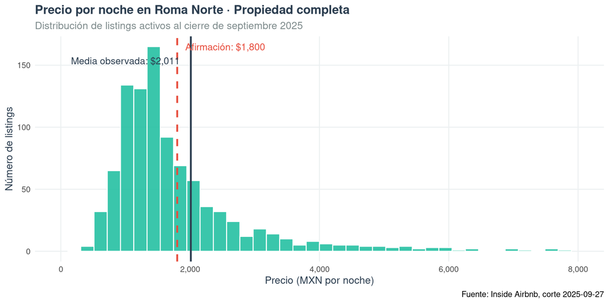

```r
ggplot(roma_norte, aes(x = precio)) +
  geom_histogram(bins = 40, fill = colores$accent,
                 color = "white", alpha = 0.85) +
  geom_vline(xintercept = 1800, color = colores$danger,
             linewidth = 1, linetype = "dashed") +
  geom_vline(xintercept = mean(roma_norte$precio),
             color = colores$primary, linewidth = 1) +
  annotate("text", x = 1800, y = Inf, label = "Afirmación: $1,800",
           color = colores$danger, hjust = -0.1, vjust = 2, size = 4) +
  annotate("text", x = mean(roma_norte$precio), y = Inf,
           label = paste0("Media observada: $",
                          format(round(mean(roma_norte$precio)), big.mark = ",")),
           color = colores$primary, hjust = 1.1, vjust = 4, size = 4) +
  scale_x_continuous(labels = label_comma(), limits = c(0, 8000)) +
  labs(
    title = "Precio por noche en Roma Norte · Propiedad completa",
    subtitle = "Distribución de listings activos al cierre de septiembre 2025",
    x = "Precio (MXN por noche)",
    y = "Número de listings",
    caption = "Fuente: Inside Airbnb, corte 2025-09-27"
  ) +
  theme_curso()
```

### 3.3 Diagnóstico de supuestos de la t-test

La prueba t de una muestra supone que la media muestral se distribuye normalmente. Con $n$ grande (por TCL) esto se cumple incluso si los datos son asimétricos. Verificamos:

```r
# Tamaño de muestra (grande → TCL aplica)
cat("n =", n_roma, "— TCL aplica si n ≥ 30\n\n")
```

```
n = 979 — TCL aplica si n ≥ 30
```

```r
# Skewness y asimetría visual
cat("Asimetría de los datos originales:\n")
```

```
Asimetría de los datos originales:
```

```r
cat("  Media      :", round(mean(roma_norte$precio), 0), "\n")
```

```
  Media      : 2011
```

```r
cat("  Mediana    :", round(median(roma_norte$precio), 0), "\n")
```

```
  Mediana    : 1491
```

```r
cat("  (Si media > mediana, los datos están sesgados a la derecha,\n")
```

```
  (Si media > mediana, los datos están sesgados a la derecha,
```

```r
cat("   típico de precios; no invalida la t-test por TCL.)\n")
```

```
   típico de precios; no invalida la t-test por TCL.)
```

## 4. Prueba de hipótesis

### 4.1 Formulación

$$H_0: \mu = 1{,}800 \quad \text{vs.} \quad H_1: \mu \neq 1{,}800$$

Nivel de significancia: $\alpha = 0.05$.

### 4.2 Ejecución

```r
prueba <- t.test(
  x           = roma_norte$precio,
  mu          = 1800,
  alternative = "two.sided",
  conf.level  = 0.95
)

prueba
```

```
    One Sample t-test

data:  roma_norte$precio
t = 3.5372, df = 978, p-value = 0.0004234
alternative hypothesis: true mean is not equal to 1800
95 percent confidence interval:
 1893.850 2127.748
sample estimates:
mean of x
 2010.799
```

### 4.3 Extracción de elementos clave para la narrativa

```r
resultados <- list(
  media_muestral   = round(mean(roma_norte$precio), 0),
  mediana_muestral = round(median(roma_norte$precio), 0),
  estadistico_t    = round(prueba$statistic, 3),
  grados_libertad  = round(prueba$parameter, 0),
  p_valor          = format.pval(prueba$p.value, digits = 3),
  ic_inf           = round(prueba$conf.int[1], 0),
  ic_sup           = round(prueba$conf.int[2], 0),
  n                = n_roma
)

# Imprimir de forma legible
cat("Media muestral       :", format(resultados$media_muestral, big.mark = ","), "MXN\n")
```

```
Media muestral       : 2,011 MXN
```

```r
cat("Mediana muestral     :", format(resultados$mediana_muestral, big.mark = ","), "MXN\n")
```

```
Mediana muestral     : 1,491 MXN
```

```r
cat("Estadístico t        :", resultados$estadistico_t, "\n")
```

```
Estadístico t        : 3.537
```

```r
cat("Grados de libertad   :", resultados$grados_libertad, "\n")
```

```
Grados de libertad   : 978
```

```r
cat("Valor-p              :", resultados$p_valor, "\n")
```

```
Valor-p              : 0.000423
```

```r
cat("IC 95% para la media : [",
    format(resultados$ic_inf, big.mark = ","), ",",
    format(resultados$ic_sup, big.mark = ","), "] MXN\n")
```

```
IC 95% para la media : [ 1,894 , 2,128 ] MXN
```

```r
cat("n                    :", resultados$n, "\n")
```

```
n                    : 979
```

## 5. Interpretación profesional

### 5.1 Decisión estadística

- **Decisión**: Rechazamos H₀ (p = 0.000423).
- **Conclusión**: La media poblacional NO es $1,800.
- **Intervalo de confianza al 95%**: entre $1,894 y $2,128 MXN.

### 5.2 Recomendación a Patricia

**Para: Patricia Domínguez** **Asunto: Validación de la referencia de $1,800 MXN**

Con base en 979 propiedades completas listadas en Roma Norte (corte del 27 de septiembre de 2025), el precio promedio observado es de **$2,011 MXN por noche**, con intervalo de confianza al 95% entre **$1,894 y $2,128 MXN**. La cifra de $1,800 mencionada en el artículo está **fuera** de ese intervalo (p = 0.000423), por lo que recomendamos no usarla como referencia para su planeación financiera.

La mediana observada es **$1,491 MXN**, y como el precio de Airbnb tiende a distribuirse de forma asimétrica (algunos listings muy caros elevan la media), puede ser una referencia más conservadora y robusta.

**Alcance y limitaciones del dato**: identificamos “Roma Norte” usando la colonia que el propio host declara en su listing. Aproximadamente el 45% de los hosts en CDMX no reportan este campo, por lo que la muestra está implícitamente condicionada a hosts que sí lo hicieron — probablemente operadores más profesionales o con más experiencia. No tenemos evidencia directa de que eso sesgue el precio promedio en una dirección específica, pero conviene tenerlo en cuenta.

**Lo que este análisis NO responde aún**: qué precio cobrar específicamente por su depto de 2 recámaras, cómo varía el precio por temporada, o cómo se compara Roma Norte con otras alcaldías. Esos análisis los trabajaremos en las siguientes sesiones.

## 6. Valores finales usados en las slides

La slide `01_marco_pruebas_hipotesis.qmd` lee estos valores vía inline `r` desde `datos/resultados_s01.rds`, así que no hay placeholders que mantener sincronizados a mano.

| Variable | Valor |
| --- | --- |
| n | 979 |
| Media muestral | $2,011 |
| Mediana | $1,491 |
| IC95% inferior | $1,894 |
| IC95% superior | $2,128 |
| Estadístico t | 3.537 |
| Grados de libertad | 978 |
| Valor-p | 0.000423 |

## 7. Preservación de resultados

Guardamos los resultados para que otras sesiones puedan referenciarlos si hace falta:

```r
saveRDS(resultados, "../datos/resultados_s01.rds")
message("Resultados guardados en datos/resultados_s01.rds")
```